# Jessica, Ibegwam, Final

Department of Mathematics

College of Arts and Sciences, Howard University

Math 014 (02) Introduction to Data Science-Honors (Spring 2025)

Final Project Part- 2

**Student Name:** Jessica Ibegwam

**Student Id:** 003100529  
**Due date:** 04-29-2025

## Importing Libraries

```python
import pandas as pd
import numpy as np
#Imports both pandas and numpy
import matplotlib.pyplot as plt
import seaborn as sns
#Imports Matlab and Seaborn for data visualization
import plotly.express as px
#Imports potly express for interactive visualization
```

## Data Loading

```python
df= pd.read_csv('diabetes_dataset.csv') #Loads dataset
```

```python
#First five rows
df.head()
```

|  | Unnamed: 0 | Age | Sex | Ethnicity | BMI | Waist_Circumference | Fasting_Blood_Glucose | HbA1c | Blood_Pressure_Systolic | Blood_Pressure_Diastolic | ... | Cholesterol_HDL | Cholesterol_LDL | GGT | Serum_Urate | Physical_Activity_Level | Dietary_Intake_Calories | Alcohol_Consumption | Smoking_Status | Family_History_of_Diabetes | Previous_Gestational_Diabetes |
| --- | --- | --- | --- | --- | --- | --- | --- | --- | --- | --- | --- | --- | --- | --- | --- | --- | --- | --- | --- | --- | --- |
| 0 | 0 | 58 | Female | White | 35.8 | 83.4 | 123.9 | 10.9 | 152 | 114 | ... | 50.2 | 99.2 | 37.5 | 7.2 | Moderate | 1538 | Moderate | Never | 0 | 1 |
| 1 | 1 | 48 | Male | Asian | 24.1 | 71.4 | 183.7 | 12.8 | 103 | 91 | ... | 62.0 | 146.4 | 88.5 | 6.1 | Moderate | 2653 | Moderate | Current | 0 | 1 |
| 2 | 2 | 34 | Female | Black | 25.0 | 113.8 | 142.0 | 14.5 | 179 | 104 | ... | 32.1 | 164.1 | 56.2 | 6.9 | Low | 1684 | Heavy | Former | 1 | 0 |
| 3 | 3 | 62 | Male | Asian | 32.7 | 100.4 | 167.4 | 8.8 | 176 | 118 | ... | 41.1 | 84.0 | 34.4 | 5.4 | Low | 3796 | Moderate | Never | 1 | 0 |
| 4 | 4 | 27 | Female | Asian | 33.5 | 110.8 | 146.4 | 7.1 | 122 | 97 | ... | 53.9 | 92.8 | 81.9 | 7.4 | Moderate | 3161 | Heavy | Current | 0 | 0 |

5 rows × 21 columns

```python
df.shape #Provides the structure of the dataset
```

```
(10000, 21)
```

```python
# Provide data types and and columns
df.info()
```

```
<class 'pandas.core.frame.DataFrame'>
RangeIndex: 10000 entries, 0 to 9999
Data columns (total 21 columns):
 #   Column                         Non-Null Count  Dtype
---  ------                         --------------  -----
 0   Unnamed: 0                     10000 non-null  int64
 1   Age                            10000 non-null  int64
 2   Sex                            10000 non-null  object
 3   Ethnicity                      10000 non-null  object
 4   BMI                            10000 non-null  float64
 5   Waist_Circumference            10000 non-null  float64
 6   Fasting_Blood_Glucose          10000 non-null  float64
 7   HbA1c                          10000 non-null  float64
 8   Blood_Pressure_Systolic        10000 non-null  int64
 9   Blood_Pressure_Diastolic       10000 non-null  int64
 10  Cholesterol_Total              10000 non-null  float64
 11  Cholesterol_HDL                10000 non-null  float64
 12  Cholesterol_LDL                10000 non-null  float64
 13  GGT                            10000 non-null  float64
 14  Serum_Urate                    10000 non-null  float64
 15  Physical_Activity_Level        10000 non-null  object
 16  Dietary_Intake_Calories        10000 non-null  int64
 17  Alcohol_Consumption            6680 non-null   object
 18  Smoking_Status                 10000 non-null  object
 19  Family_History_of_Diabetes     10000 non-null  int64
 20  Previous_Gestational_Diabetes  10000 non-null  int64
dtypes: float64(9), int64(7), object(5)
memory usage: 1.6+ MB
```

```python
df.columns
# Lists all columns of interests
```

```
Index(['Unnamed: 0', 'Age', 'Sex', 'Ethnicity', 'BMI', 'Waist_Circumference',
       'Fasting_Blood_Glucose', 'HbA1c', 'Blood_Pressure_Systolic',
       'Blood_Pressure_Diastolic', 'Cholesterol_Total', 'Cholesterol_HDL',
       'Cholesterol_LDL', 'GGT', 'Serum_Urate', 'Physical_Activity_Level',
       'Dietary_Intake_Calories', 'Alcohol_Consumption', 'Smoking_Status',
       'Family_History_of_Diabetes', 'Previous_Gestational_Diabetes'],
      dtype='object')
```

```python
df.isnull().sum()
# Summary of null values in each column
```

```
Unnamed: 0                          0
Age                                 0
Sex                                 0
Ethnicity                           0
BMI                                 0
Waist_Circumference                 0
Fasting_Blood_Glucose               0
HbA1c                               0
Blood_Pressure_Systolic             0
Blood_Pressure_Diastolic            0
Cholesterol_Total                   0
Cholesterol_HDL                     0
Cholesterol_LDL                     0
GGT                                 0
Serum_Urate                         0
Physical_Activity_Level             0
Dietary_Intake_Calories             0
Alcohol_Consumption              3320
Smoking_Status                      0
Family_History_of_Diabetes          0
Previous_Gestational_Diabetes       0
dtype: int64
```

## Data Understanding and Cleaning

Here, I plan to: I plan to

- Drop the Unnamed column and Alcohol_Consumption Column
- Rename a few columns
- And add new categories

```python
df_clean=df.copy() #Copies the dataset into a new variable for cleaning
```

```python
df_clean = df_clean.drop('Unnamed: 0', axis=1) # Dropping the Unnamed: 0 column in the dataset
df_clean = df_clean.drop('Alcohol_Consumption', axis=1) #Dropping the column with null values
```

I am going to convert Family History of Diabetes and Precious Gestational Diabetes into categorical columns. These the binary system is used for yes and no answers, so it is not numerical.

```python
categorical_data = ['Family_History_of_Diabetes', 'Previous_Gestational_Diabetes']  #Stores columns into variable. I had to remove Age from here sorry.
df_clean[categorical_data] = df_clean[categorical_data].astype(str) #Convertes these columns into strings, so it can show up as objects
```

```python
df_clean.info() #Checking the data types for those columns
```

```
<class 'pandas.core.frame.DataFrame'>
RangeIndex: 10000 entries, 0 to 9999
Data columns (total 19 columns):
 #   Column                         Non-Null Count  Dtype
---  ------                         --------------  -----
 0   Age                            10000 non-null  int64
 1   Sex                            10000 non-null  object
 2   Ethnicity                      10000 non-null  object
 3   BMI                            10000 non-null  float64
 4   Waist_Circumference            10000 non-null  float64
 5   Fasting_Blood_Glucose          10000 non-null  float64
 6   HbA1c                          10000 non-null  float64
 7   Blood_Pressure_Systolic        10000 non-null  int64
 8   Blood_Pressure_Diastolic       10000 non-null  int64
 9   Cholesterol_Total              10000 non-null  float64
 10  Cholesterol_HDL                10000 non-null  float64
 11  Cholesterol_LDL                10000 non-null  float64
 12  GGT                            10000 non-null  float64
 13  Serum_Urate                    10000 non-null  float64
 14  Physical_Activity_Level        10000 non-null  object
 15  Dietary_Intake_Calories        10000 non-null  int64
 16  Smoking_Status                 10000 non-null  object
 17  Family_History_of_Diabetes     10000 non-null  object
 18  Previous_Gestational_Diabetes  10000 non-null  object
dtypes: float64(9), int64(4), object(6)
memory usage: 1.4+ MB
```

```python
df_clean.duplicated().sum() #Checks for duplicates
```

```
0
```

Since, they are no duplicates, I will rename columns

```python
df_clean = df_clean.rename(columns={
    'Family_History_of_Diabetes': 'Family_History',
    "Dietary_Intake_Calories" : "Caloric_Intake",
    "Fasting_Blood_Glucose" : "Fasting_Glucose",
    'Blood_Pressure_Systolic': 'BP_Systolic',
    'Blood_Pressure_Diastolic': 'BP_Diastolic'}) #Renames these columns into something shorter and easier to remember
```

```python
df_clean
```

|  | Age | Sex | Ethnicity | BMI | Waist_Circumference | Fasting_Glucose | HbA1c | BP_Systolic | BP_Diastolic | Cholesterol_Total | Cholesterol_HDL | Cholesterol_LDL | GGT | Serum_Urate | Physical_Activity_Level | Caloric_Intake | Smoking_Status | Family_History | Previous_Gestational_Diabetes |
| --- | --- | --- | --- | --- | --- | --- | --- | --- | --- | --- | --- | --- | --- | --- | --- | --- | --- | --- | --- |
| 0 | 58 | Female | White | 35.8 | 83.4 | 123.9 | 10.9 | 152 | 114 | 197.8 | 50.2 | 99.2 | 37.5 | 7.2 | Moderate | 1538 | Never | 0 | 1 |
| 1 | 48 | Male | Asian | 24.1 | 71.4 | 183.7 | 12.8 | 103 | 91 | 261.6 | 62.0 | 146.4 | 88.5 | 6.1 | Moderate | 2653 | Current | 0 | 1 |
| 2 | 34 | Female | Black | 25.0 | 113.8 | 142.0 | 14.5 | 179 | 104 | 261.0 | 32.1 | 164.1 | 56.2 | 6.9 | Low | 1684 | Former | 1 | 0 |
| 3 | 62 | Male | Asian | 32.7 | 100.4 | 167.4 | 8.8 | 176 | 118 | 183.4 | 41.1 | 84.0 | 34.4 | 5.4 | Low | 3796 | Never | 1 | 0 |
| 4 | 27 | Female | Asian | 33.5 | 110.8 | 146.4 | 7.1 | 122 | 97 | 203.2 | 53.9 | 92.8 | 81.9 | 7.4 | Moderate | 3161 | Current | 0 | 0 |
| ... | ... | ... | ... | ... | ... | ... | ... | ... | ... | ... | ... | ... | ... | ... | ... | ... | ... | ... | ... |
| 9995 | 45 | Female | Asian | 39.4 | 114.0 | 76.2 | 13.4 | 109 | 82 | 187.7 | 60.3 | 88.7 | 19.1 | 6.1 | Low | 3582 | Former | 1 | 1 |
| 9996 | 41 | Female | Asian | 21.0 | 71.3 | 77.1 | 12.9 | 154 | 72 | 234.3 | 72.3 | 200.0 | 37.1 | 3.5 | Low | 2206 | Never | 1 | 1 |
| 9997 | 50 | Female | Asian | 29.0 | 106.3 | 97.5 | 4.9 | 122 | 61 | 266.0 | 69.8 | 156.1 | 85.8 | 4.9 | High | 3175 | Former | 1 | 1 |
| 9998 | 62 | Female | White | 27.3 | 119.9 | 89.0 | 11.5 | 99 | 115 | 172.3 | 74.2 | 110.9 | 25.3 | 5.2 | High | 3478 | Never | 1 | 0 |
| 9999 | 29 | Male | Black | 20.6 | 102.0 | 70.8 | 14.5 | 156 | 64 | 277.9 | 38.0 | 108.1 | 68.5 | 6.0 | Low | 2918 | Former | 1 | 0 |

10000 rows × 19 columns

#### BMI Status Category

```python
def BMI_Category(BMI): #Creates a function for the BMI category
    if BMI < 18.5:
        return 'Underweight' #If the BMI value is less than the condition, then the category would be underweight
    elif 18.5 <= BMI < 24.9: #If it is within the range, the patient has normal weight
        return 'Normal'
    elif 25 <= BMI < 29.9: #If it is within this range, the patient is overweight.
        return 'Overweight'
    else:
        return 'Obese' #If it is over all these ranges, the function would return obese

df_clean['BMI_Category'] = df_clean['BMI'].apply(BMI_Category) #Saves this function to the dataset
```

```python
df_clean
```

|  | Age | Sex | Ethnicity | BMI | Waist_Circumference | Fasting_Glucose | HbA1c | BP_Systolic | BP_Diastolic | Cholesterol_Total | Cholesterol_HDL | Cholesterol_LDL | GGT | Serum_Urate | Physical_Activity_Level | Caloric_Intake | Smoking_Status | Family_History | Previous_Gestational_Diabetes | BMI_Category |
| --- | --- | --- | --- | --- | --- | --- | --- | --- | --- | --- | --- | --- | --- | --- | --- | --- | --- | --- | --- | --- |
| 0 | 58 | Female | White | 35.8 | 83.4 | 123.9 | 10.9 | 152 | 114 | 197.8 | 50.2 | 99.2 | 37.5 | 7.2 | Moderate | 1538 | Never | 0 | 1 | Obese |
| 1 | 48 | Male | Asian | 24.1 | 71.4 | 183.7 | 12.8 | 103 | 91 | 261.6 | 62.0 | 146.4 | 88.5 | 6.1 | Moderate | 2653 | Current | 0 | 1 | Normal |
| 2 | 34 | Female | Black | 25.0 | 113.8 | 142.0 | 14.5 | 179 | 104 | 261.0 | 32.1 | 164.1 | 56.2 | 6.9 | Low | 1684 | Former | 1 | 0 | Overweight |
| 3 | 62 | Male | Asian | 32.7 | 100.4 | 167.4 | 8.8 | 176 | 118 | 183.4 | 41.1 | 84.0 | 34.4 | 5.4 | Low | 3796 | Never | 1 | 0 | Obese |
| 4 | 27 | Female | Asian | 33.5 | 110.8 | 146.4 | 7.1 | 122 | 97 | 203.2 | 53.9 | 92.8 | 81.9 | 7.4 | Moderate | 3161 | Current | 0 | 0 | Obese |
| ... | ... | ... | ... | ... | ... | ... | ... | ... | ... | ... | ... | ... | ... | ... | ... | ... | ... | ... | ... | ... |
| 9995 | 45 | Female | Asian | 39.4 | 114.0 | 76.2 | 13.4 | 109 | 82 | 187.7 | 60.3 | 88.7 | 19.1 | 6.1 | Low | 3582 | Former | 1 | 1 | Obese |
| 9996 | 41 | Female | Asian | 21.0 | 71.3 | 77.1 | 12.9 | 154 | 72 | 234.3 | 72.3 | 200.0 | 37.1 | 3.5 | Low | 2206 | Never | 1 | 1 | Normal |
| 9997 | 50 | Female | Asian | 29.0 | 106.3 | 97.5 | 4.9 | 122 | 61 | 266.0 | 69.8 | 156.1 | 85.8 | 4.9 | High | 3175 | Former | 1 | 1 | Overweight |
| 9998 | 62 | Female | White | 27.3 | 119.9 | 89.0 | 11.5 | 99 | 115 | 172.3 | 74.2 | 110.9 | 25.3 | 5.2 | High | 3478 | Never | 1 | 0 | Overweight |
| 9999 | 29 | Male | Black | 20.6 | 102.0 | 70.8 | 14.5 | 156 | 64 | 277.9 | 38.0 | 108.1 | 68.5 | 6.0 | Low | 2918 | Former | 1 | 0 | Normal |

10000 rows × 20 columns

#### Creating an Age Group Column

```python
def Age_Group(Age): #Creates a function for age groups
    if Age < 18:
        return 'Child'
    elif 18 <= Age < 26:
        return 'Young Adult' #This provides a range for the young adult as according to the Society for Adolescent Health and Medicine
    elif 26 <= Age < 60:
        return 'Adult'
    else:
        return 'Senior' #If the value is above all the ranges, then the function would return senior

df_clean['Age_Group'] = df_clean['Age'].apply(Age_Group) #Applies function to the dataset
```

```python
df_clean
```

|  | Age | Sex | Ethnicity | BMI | Waist_Circumference | Fasting_Glucose | HbA1c | BP_Systolic | BP_Diastolic | Cholesterol_Total | ... | Cholesterol_LDL | GGT | Serum_Urate | Physical_Activity_Level | Caloric_Intake | Smoking_Status | Family_History | Previous_Gestational_Diabetes | BMI_Category | Age_Group |
| --- | --- | --- | --- | --- | --- | --- | --- | --- | --- | --- | --- | --- | --- | --- | --- | --- | --- | --- | --- | --- | --- |
| 0 | 58 | Female | White | 35.8 | 83.4 | 123.9 | 10.9 | 152 | 114 | 197.8 | ... | 99.2 | 37.5 | 7.2 | Moderate | 1538 | Never | 0 | 1 | Obese | Adult |
| 1 | 48 | Male | Asian | 24.1 | 71.4 | 183.7 | 12.8 | 103 | 91 | 261.6 | ... | 146.4 | 88.5 | 6.1 | Moderate | 2653 | Current | 0 | 1 | Normal | Adult |
| 2 | 34 | Female | Black | 25.0 | 113.8 | 142.0 | 14.5 | 179 | 104 | 261.0 | ... | 164.1 | 56.2 | 6.9 | Low | 1684 | Former | 1 | 0 | Overweight | Adult |
| 3 | 62 | Male | Asian | 32.7 | 100.4 | 167.4 | 8.8 | 176 | 118 | 183.4 | ... | 84.0 | 34.4 | 5.4 | Low | 3796 | Never | 1 | 0 | Obese | Senior |
| 4 | 27 | Female | Asian | 33.5 | 110.8 | 146.4 | 7.1 | 122 | 97 | 203.2 | ... | 92.8 | 81.9 | 7.4 | Moderate | 3161 | Current | 0 | 0 | Obese | Adult |
| ... | ... | ... | ... | ... | ... | ... | ... | ... | ... | ... | ... | ... | ... | ... | ... | ... | ... | ... | ... | ... | ... |
| 9995 | 45 | Female | Asian | 39.4 | 114.0 | 76.2 | 13.4 | 109 | 82 | 187.7 | ... | 88.7 | 19.1 | 6.1 | Low | 3582 | Former | 1 | 1 | Obese | Adult |
| 9996 | 41 | Female | Asian | 21.0 | 71.3 | 77.1 | 12.9 | 154 | 72 | 234.3 | ... | 200.0 | 37.1 | 3.5 | Low | 2206 | Never | 1 | 1 | Normal | Adult |
| 9997 | 50 | Female | Asian | 29.0 | 106.3 | 97.5 | 4.9 | 122 | 61 | 266.0 | ... | 156.1 | 85.8 | 4.9 | High | 3175 | Former | 1 | 1 | Overweight | Adult |
| 9998 | 62 | Female | White | 27.3 | 119.9 | 89.0 | 11.5 | 99 | 115 | 172.3 | ... | 110.9 | 25.3 | 5.2 | High | 3478 | Never | 1 | 0 | Overweight | Senior |
| 9999 | 29 | Male | Black | 20.6 | 102.0 | 70.8 | 14.5 | 156 | 64 | 277.9 | ... | 108.1 | 68.5 | 6.0 | Low | 2918 | Former | 1 | 0 | Normal | Adult |

10000 rows × 21 columns

#### HbA1C Status

```python
def HbA1c_Status(HbA1c):#Creates a function with conditions that adheres to the medical diagnoses for diabetes
    if HbA1c < 5.7:
        return 'Within Normal Range'
    elif 5.7 <= HbA1c < 6.5:
        return 'Within Prediabetes Range'
    else:
        return 'Within Diabetes Range'

df_clean['HbA1c_Status'] = df_clean['HbA1c'].apply(HbA1c_Status) #Applies function to the dataset
```

```python
df_clean
```

|  | Age | Sex | Ethnicity | BMI | Waist_Circumference | Fasting_Glucose | HbA1c | BP_Systolic | BP_Diastolic | Cholesterol_Total | ... | GGT | Serum_Urate | Physical_Activity_Level | Caloric_Intake | Smoking_Status | Family_History | Previous_Gestational_Diabetes | BMI_Category | Age_Group | HbA1c_Status |
| --- | --- | --- | --- | --- | --- | --- | --- | --- | --- | --- | --- | --- | --- | --- | --- | --- | --- | --- | --- | --- | --- |
| 0 | 58 | Female | White | 35.8 | 83.4 | 123.9 | 10.9 | 152 | 114 | 197.8 | ... | 37.5 | 7.2 | Moderate | 1538 | Never | 0 | 1 | Obese | Adult | Within Diabetes Range |
| 1 | 48 | Male | Asian | 24.1 | 71.4 | 183.7 | 12.8 | 103 | 91 | 261.6 | ... | 88.5 | 6.1 | Moderate | 2653 | Current | 0 | 1 | Normal | Adult | Within Diabetes Range |
| 2 | 34 | Female | Black | 25.0 | 113.8 | 142.0 | 14.5 | 179 | 104 | 261.0 | ... | 56.2 | 6.9 | Low | 1684 | Former | 1 | 0 | Overweight | Adult | Within Diabetes Range |
| 3 | 62 | Male | Asian | 32.7 | 100.4 | 167.4 | 8.8 | 176 | 118 | 183.4 | ... | 34.4 | 5.4 | Low | 3796 | Never | 1 | 0 | Obese | Senior | Within Diabetes Range |
| 4 | 27 | Female | Asian | 33.5 | 110.8 | 146.4 | 7.1 | 122 | 97 | 203.2 | ... | 81.9 | 7.4 | Moderate | 3161 | Current | 0 | 0 | Obese | Adult | Within Diabetes Range |
| ... | ... | ... | ... | ... | ... | ... | ... | ... | ... | ... | ... | ... | ... | ... | ... | ... | ... | ... | ... | ... | ... |
| 9995 | 45 | Female | Asian | 39.4 | 114.0 | 76.2 | 13.4 | 109 | 82 | 187.7 | ... | 19.1 | 6.1 | Low | 3582 | Former | 1 | 1 | Obese | Adult | Within Diabetes Range |
| 9996 | 41 | Female | Asian | 21.0 | 71.3 | 77.1 | 12.9 | 154 | 72 | 234.3 | ... | 37.1 | 3.5 | Low | 2206 | Never | 1 | 1 | Normal | Adult | Within Diabetes Range |
| 9997 | 50 | Female | Asian | 29.0 | 106.3 | 97.5 | 4.9 | 122 | 61 | 266.0 | ... | 85.8 | 4.9 | High | 3175 | Former | 1 | 1 | Overweight | Adult | Within Normal Range |
| 9998 | 62 | Female | White | 27.3 | 119.9 | 89.0 | 11.5 | 99 | 115 | 172.3 | ... | 25.3 | 5.2 | High | 3478 | Never | 1 | 0 | Overweight | Senior | Within Diabetes Range |
| 9999 | 29 | Male | Black | 20.6 | 102.0 | 70.8 | 14.5 | 156 | 64 | 277.9 | ... | 68.5 | 6.0 | Low | 2918 | Former | 1 | 0 | Normal | Adult | Within Diabetes Range |

10000 rows × 22 columns

#### Hypertension Risk Indicators

```python
def Blood_Pressure_Status(BP_Systolic): #Creates a function with conditions that adheres to the medical evaluation of blood pressure
    if 90 < BP_Systolic < 120:
        return 'Normal'
    elif 120 <= BP_Systolic < 130:
        return 'Elevated'
    elif 130 <= BP_Systolic < 140:
        return 'Stage 1'
    elif BP_Systolic >= 140:
        return 'Stage 2'
    else:
        return 'Hypotension' #If the value is lower than these ranges, then the patient has low blood pressure

df_clean['Blood_Pressure_Status'] = df_clean['BP_Systolic'].apply(Blood_Pressure_Status) #Applies function to the dataset
```

```python
df_clean
```

|  | Age | Sex | Ethnicity | BMI | Waist_Circumference | Fasting_Glucose | HbA1c | BP_Systolic | BP_Diastolic | Cholesterol_Total | ... | Serum_Urate | Physical_Activity_Level | Caloric_Intake | Smoking_Status | Family_History | Previous_Gestational_Diabetes | BMI_Category | Age_Group | HbA1c_Status | Blood_Pressure_Status |
| --- | --- | --- | --- | --- | --- | --- | --- | --- | --- | --- | --- | --- | --- | --- | --- | --- | --- | --- | --- | --- | --- |
| 0 | 58 | Female | White | 35.8 | 83.4 | 123.9 | 10.9 | 152 | 114 | 197.8 | ... | 7.2 | Moderate | 1538 | Never | 0 | 1 | Obese | Adult | Within Diabetes Range | Stage 2 |
| 1 | 48 | Male | Asian | 24.1 | 71.4 | 183.7 | 12.8 | 103 | 91 | 261.6 | ... | 6.1 | Moderate | 2653 | Current | 0 | 1 | Normal | Adult | Within Diabetes Range | Normal |
| 2 | 34 | Female | Black | 25.0 | 113.8 | 142.0 | 14.5 | 179 | 104 | 261.0 | ... | 6.9 | Low | 1684 | Former | 1 | 0 | Overweight | Adult | Within Diabetes Range | Stage 2 |
| 3 | 62 | Male | Asian | 32.7 | 100.4 | 167.4 | 8.8 | 176 | 118 | 183.4 | ... | 5.4 | Low | 3796 | Never | 1 | 0 | Obese | Senior | Within Diabetes Range | Stage 2 |
| 4 | 27 | Female | Asian | 33.5 | 110.8 | 146.4 | 7.1 | 122 | 97 | 203.2 | ... | 7.4 | Moderate | 3161 | Current | 0 | 0 | Obese | Adult | Within Diabetes Range | Elevated |
| ... | ... | ... | ... | ... | ... | ... | ... | ... | ... | ... | ... | ... | ... | ... | ... | ... | ... | ... | ... | ... | ... |
| 9995 | 45 | Female | Asian | 39.4 | 114.0 | 76.2 | 13.4 | 109 | 82 | 187.7 | ... | 6.1 | Low | 3582 | Former | 1 | 1 | Obese | Adult | Within Diabetes Range | Normal |
| 9996 | 41 | Female | Asian | 21.0 | 71.3 | 77.1 | 12.9 | 154 | 72 | 234.3 | ... | 3.5 | Low | 2206 | Never | 1 | 1 | Normal | Adult | Within Diabetes Range | Stage 2 |
| 9997 | 50 | Female | Asian | 29.0 | 106.3 | 97.5 | 4.9 | 122 | 61 | 266.0 | ... | 4.9 | High | 3175 | Former | 1 | 1 | Overweight | Adult | Within Normal Range | Elevated |
| 9998 | 62 | Female | White | 27.3 | 119.9 | 89.0 | 11.5 | 99 | 115 | 172.3 | ... | 5.2 | High | 3478 | Never | 1 | 0 | Overweight | Senior | Within Diabetes Range | Normal |
| 9999 | 29 | Male | Black | 20.6 | 102.0 | 70.8 | 14.5 | 156 | 64 | 277.9 | ... | 6.0 | Low | 2918 | Former | 1 | 0 | Normal | Adult | Within Diabetes Range | Stage 2 |

10000 rows × 23 columns

### Exploratory Data

- Here, I will use .value_counts() and groupby (mean) to analyze the data)

#### Understanding Blood Sugar

- Fasting Glucose
- HbA1C
- Diabetes Status

```python
df_clean['HbA1c_Status'].value_counts()
```

```
HbA1c_Status
Within Diabetes Range       7784
Within Normal Range         1471
Within Prediabetes Range     745
Name: count, dtype: int64
```

```python
df_clean[['Fasting_Glucose', 'HbA1c']].describe()
```

|  | Fasting_Glucose | HbA1c |
| --- | --- | --- |
| count | 10000.000000 | 10000.000000 |
| mean | 134.776210 | 9.507510 |
| std | 37.633544 | 3.176421 |
| min | 70.000000 | 4.000000 |
| 25% | 102.175000 | 6.800000 |
| 50% | 134.500000 | 9.500000 |
| 75% | 167.800000 | 12.300000 |
| max | 200.000000 | 15.000000 |

```python
df_clean[['BMI', 'Waist_Circumference',"Caloric_Intake"]].describe() #Provides statistical description of these variables
```

|  | BMI | Waist_Circumference | Caloric_Intake |
| --- | --- | --- | --- |
| count | 10000.000000 | 10000.00000 | 10000.000000 |
| mean | 29.418150 | 94.79707 | 2742.481900 |
| std | 6.170866 | 14.38329 | 716.643803 |
| min | 18.500000 | 70.00000 | 1500.000000 |
| 25% | 24.100000 | 82.20000 | 2129.000000 |
| 50% | 29.500000 | 94.90000 | 2727.000000 |
| 75% | 34.700000 | 107.00000 | 3368.000000 |
| max | 40.000000 | 120.00000 | 3999.000000 |

- Not much could be interprtated from here

```python
df_clean["Physical_Activity_Level"].value_counts() #Provides the amount of unique values for each category
```

```
Physical_Activity_Level
Low         3372
High        3341
Moderate    3287
Name: count, dtype: int64
```

- The amount for each category is almost the same. However, more patients have low activity levels.

#### Understanding Health History

```python
df_clean.columns #Shows columns. I just needed the names, since the dataset does not show all of them
```

```
Index(['Age', 'Sex', 'Ethnicity', 'BMI', 'Waist_Circumference',
       'Fasting_Glucose', 'HbA1c', 'BP_Systolic', 'BP_Diastolic',
       'Cholesterol_Total', 'Cholesterol_HDL', 'Cholesterol_LDL', 'GGT',
       'Serum_Urate', 'Physical_Activity_Level', 'Caloric_Intake',
       'Smoking_Status', 'Family_History', 'Previous_Gestational_Diabetes',
       'BMI_Category', 'Age_Group', 'HbA1c_Status', 'Blood_Pressure_Status'],
      dtype='object')
```

```python
df_clean[['BP_Systolic',	'BP_Diastolic',"Cholesterol_Total", "Cholesterol_HDL", 'Cholesterol_LDL', 'GGT',
       'Serum_Urate']].describe() #Provides statistical analysis for these values.
```

|  | BP_Systolic | BP_Diastolic | Cholesterol_Total | Cholesterol_HDL | Cholesterol_LDL | GGT | Serum_Urate |
| --- | --- | --- | --- | --- | --- | --- | --- |
| count | 10000.000000 | 10000.000000 | 10000.000000 | 10000.000000 | 10000.00000 | 10000.00000 | 10000.000000 |
| mean | 134.163700 | 89.558700 | 225.165540 | 55.019340 | 134.35377 | 55.16822 | 5.503430 |
| std | 26.110317 | 17.237792 | 42.963744 | 14.537371 | 37.50238 | 25.88180 | 1.455091 |
| min | 90.000000 | 60.000000 | 150.000000 | 30.000000 | 70.00000 | 10.00000 | 3.000000 |
| 25% | 112.000000 | 75.000000 | 187.875000 | 42.300000 | 101.67500 | 32.60000 | 4.200000 |
| 50% | 134.000000 | 89.000000 | 225.500000 | 55.200000 | 134.40000 | 55.45000 | 5.500000 |
| 75% | 157.000000 | 105.000000 | 262.400000 | 67.900000 | 166.40000 | 77.50000 | 6.800000 |
| max | 179.000000 | 119.000000 | 300.000000 | 80.000000 | 200.00000 | 100.00000 | 8.000000 |

- HDL and GGT have similar means.

```python
df_clean['Blood_Pressure_Status'].value_counts() # Shows unique values for this column
```

```
Blood_Pressure_Status
Stage 2        4388
Normal         3293
Elevated       1131
Stage 1        1094
Hypotension      94
Name: count, dtype: int64
```

- Almost half of the patients have stage 2 hypertension.
- 1/3 of the patients have a normal blood pressure

```python
df_clean['Smoking_Status'].value_counts() # Shows unique values for this column
```

```
Smoking_Status
Current    3364
Former     3330
Never      3306
Name: count, dtype: int64
```

- The smoking status is almost evenly distributed.
- However, a little more people are current smokers. There are lesser amount of people who never smoked

```python
df_clean['Previous_Gestational_Diabetes'].value_counts() # Shows unique values for this column
```

```
Previous_Gestational_Diabetes
1    5165
0    4835
Name: count, dtype: int64
```

```python
df_clean['Family_History'].value_counts() # Shows unique values for this column
```

```
Family_History
1    5070
0    4930
Name: count, dtype: int64
```

- A little more than half of the patients in the dataset have a family history of diabetes

### Grouping Risks Indicators

#### Ethnicity vs Risk Factors

```python
ethnicity_risk = df_clean.groupby('Ethnicity')[['BP_Systolic', 'BMI', 'Fasting_Glucose', 'GGT', 'Serum_Urate', 'Cholesterol_LDL']].mean()
ethnicity_risk #Groups Ethnitity by the means of the labwork results
```

| Ethnicity | BP_Systolic | BMI | Fasting_Glucose | GGT | Serum_Urate | Cholesterol_LDL |
| --- | --- | --- | --- | --- | --- | --- |
| Asian | 134.501398 | 29.242509 | 136.011027 | 55.565921 | 5.522693 | 134.695006 |
| Black | 135.231981 | 29.430839 | 135.109807 | 54.514494 | 5.479716 | 134.415794 |
| Hispanic | 133.120355 | 29.485945 | 133.887561 | 55.719265 | 5.506785 | 133.827544 |
| White | 133.771152 | 29.514666 | 134.076189 | 54.886180 | 5.504915 | 134.471152 |

```python
age_risk  = df_clean.groupby('Age_Group')[['BP_Systolic','HbA1c', 'BMI', 'Fasting_Glucose', 'GGT', 'Serum_Urate', 'Cholesterol_LDL']].mean()
age_risk #Groups Age by the means of the labwork results and stores it in the variable
```

| Age_Group | BP_Systolic | HbA1c | BMI | Fasting_Glucose | GGT | Serum_Urate | Cholesterol_LDL |
| --- | --- | --- | --- | --- | --- | --- | --- |
| Adult | 134.142398 | 9.495541 | 29.377383 | 134.149181 | 55.181418 | 5.494152 | 134.295161 |
| Senior | 134.643684 | 9.549421 | 29.557625 | 135.988173 | 54.879316 | 5.488777 | 134.750679 |
| Young Adult | 133.474851 | 9.506309 | 29.419608 | 136.379540 | 55.580648 | 5.582353 | 134.023188 |

*Adults have a higher mean for none of these columns

```python
#Saving the cleaned dataset.
df_clean.to_csv("diabetes_dataset_clean.csv")
```

# Visualization

## Heatmap

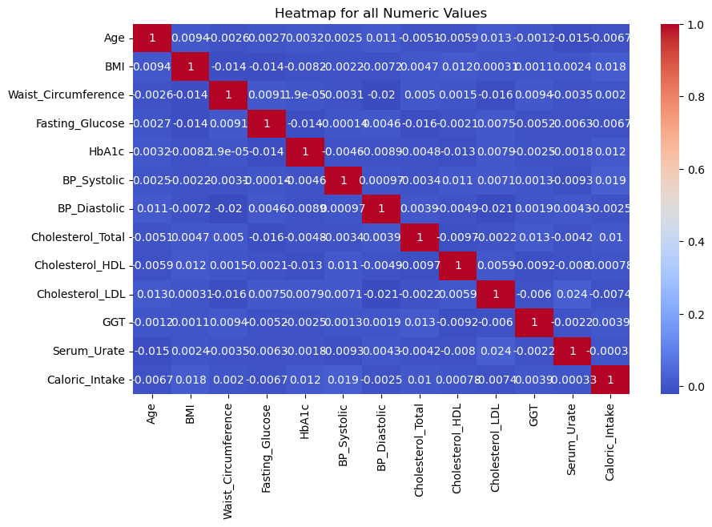

```python
corrmatrix= df_clean.corr(numeric_only=True) #Calculates the correlation and saves it in a variable
plt.figure(figsize= (10,6)) #Customizes the size of the heatmap
sns.heatmap(corrmatrix, annot= True, cmap = 'coolwarm') #Creates the heatmap using a variable
plt.title('Heatmap for all Numeric Values') #Provides title
plt.show() #Shows heat map
```

- There are barely any strong correlations between the values.

## Family History vs. Gender

```python
df_clean['Family_History'] = df_clean['Family_History'].replace({1: 'Yes', 0: 'No'}).astype('category') #Replaces the binary system as yes and no.
```

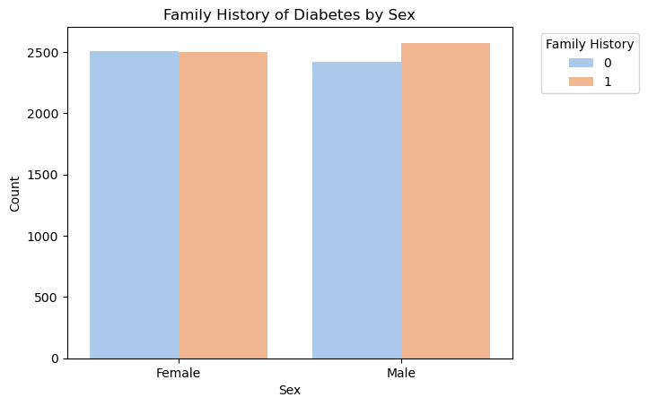

```python
#Code below is used to make a countplot with family history vs gender
sns. countplot(data=df_clean, x='Sex', hue='Family_History', palette='pastel')
# Provides labels for the countplot
plt.title('Family History of Diabetes by Sex')
plt.xlabel('Sex')
plt.ylabel('Count')
plt.legend(title='Family History', bbox_to_anchor=(1.05, 1), loc='upper left') #Customizes and labels the color key

plt.show() #Shows graph
```

- Men are more likely to have a family history then women. For women, it is about 50:50 chance of having a family history of diabetes.

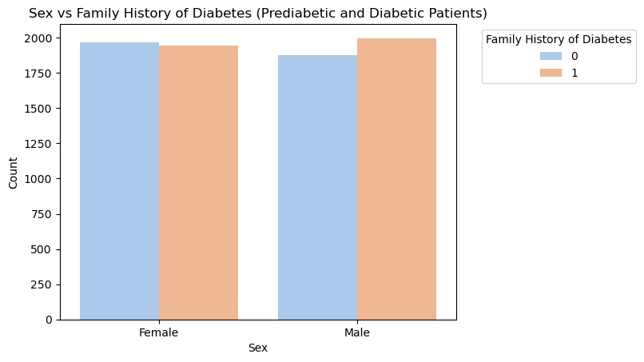

```python
filtered_df_clean = df_clean[df_clean['HbA1c_Status'].isin(['Within Preiabetes Range', 'Within Diabetes Range'])]
# The Code below is used to make a countplot with family history
sns.countplot(data=filtered_df_clean, x='Sex',hue='Family_History',  palette='pastel') #Filters the data, so that only diabetic and prediabetic patients are considered
# Hue colors the graph by the Family history, and the color pallet is pastel

# Provides labels for the countplot
plt.title('Sex vs Family History of Diabetes (Prediabetic and Diabetic Patients)')
plt.xlabel('Sex')
plt.ylabel('Count')
plt.legend(title='Family History of Diabetes', bbox_to_anchor=(1.05, 1), loc='upper left') #Customizes the color key/legend
plt.show() #shows graph
```

- After filtering,the data is still about the same as the previous countplot. However, the difference in women is a little bit larger.

### Gender vs Diabetes

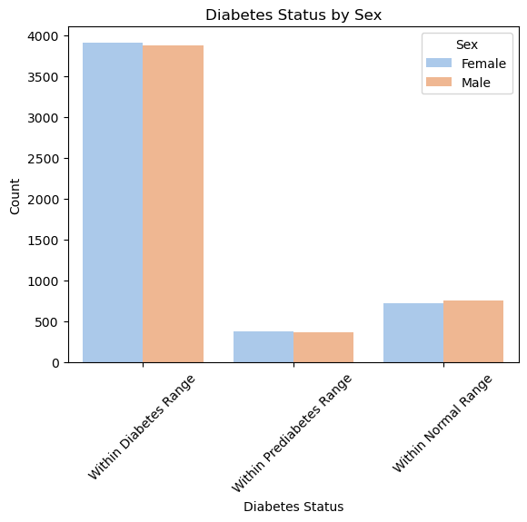

```python
#Below, the code creates a countplot that compares the diabetes status between genders
sns.countplot(data=df_clean, x='HbA1c_Status',  hue='Sex',palette='pastel')
# Hue colors the graph by the gender, and the color palette is pastel

#Provides a label and a legend
plt.title('Diabetes Status by Sex')
plt.xlabel('Diabetes Status')
plt.ylabel('Count')
plt.legend(title='Sex')
plt.xticks(rotation=45)
plt.savefig("DSGender.jpg") #Saves graph as jpg
plt.show() #Shows data
```

- Women are more likely to be prediabetic and diabetic compared to men.

### BMI by Ethnicity

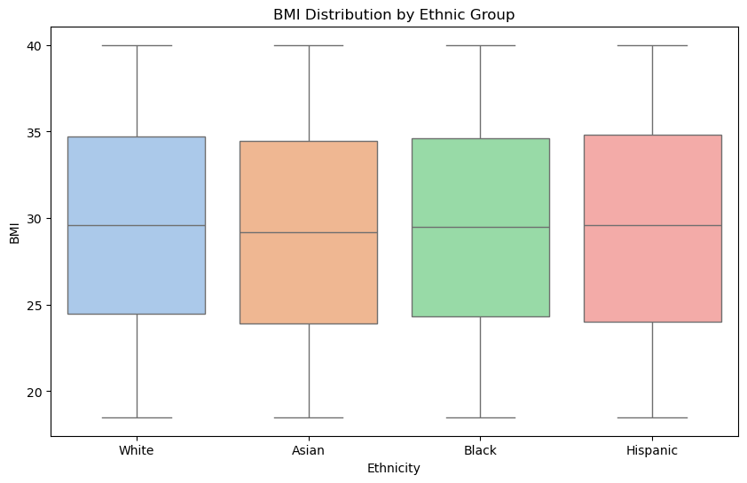

```python
plt.figure(figsize=(10, 6)) #Determines graph size
sns.boxplot(data=df_clean, x='Ethnicity', y='BMI', hue='Ethnicity', palette='pastel') #Ctreates a boxplot for BMI vs ethnic groups
# Hue colors the graph by the  Ethnicity, and the color pallete is pastel

#Provides labels
plt.title('BMI Distribution by Ethnic Group')
plt.xlabel('Ethnicity')
plt.ylabel('BMI')

plt.show() #Shows graph
```

- Barely any variance between ethnities. However, Hispanic ethnitity has the highest median compared to the rest.

## Fasting Blood Glucose

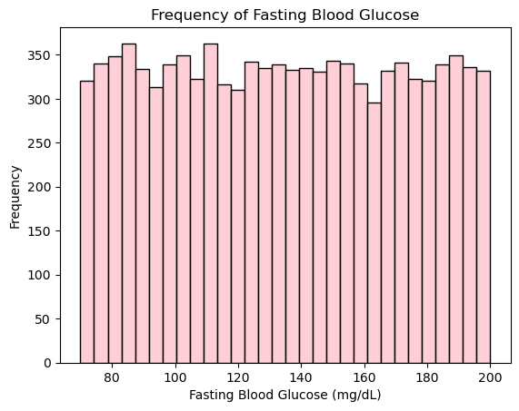

```python
sns.histplot(df_clean['Fasting_Glucose'], bins=30, color='pink') #Shows the frequency of Fasting Glucose in a pink color

# Provides labels
plt.title('Frequency of Fasting Blood Glucose')
plt.xlabel('Fasting Blood Glucose (mg/dL)')
plt.ylabel('Frequency')

plt.show() #Shows the graph
```

## HbA1c by Activity Level

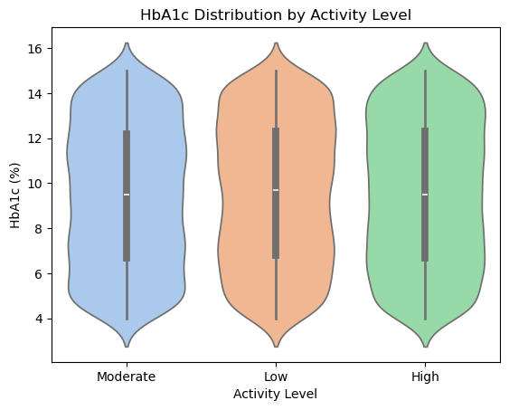

```python
sns.violinplot(data=df_clean, x='Physical_Activity_Level', y='HbA1c', hue= 'Physical_Activity_Level', palette='pastel') #Creates a violin plot to show distrubition of A1c by the Activity level
# Hue colors the graph by the Activity level, and the color pallet is pastel
#Provides labels
plt.title('HbA1c Distribution by Activity Level')
plt.xlabel('Activity Level')
plt.ylabel('HbA1c (%)')
plt.savefig("A1cactivity.jpg") #saves graph as jpg
plt.show() #Shows the graph
```

- For the moderate violin plot, it is wider at the lower A1c values. Moderate physical acitivty levels correlate to lower A1c levels and the reduction of developing diabetes
- For the low violin plot, it is wider at the higher A1c values. Therefore, low physical activity levels correlate to higher A1c levels and an increased risk of diabetes.
- For the high violin plot, it looks evenly distrubted at all A1c values. Therefore, high physiical acitivity levels do not have much affect on diabetes.

## BMI vs. Waist Circumference

```python
bmi_waist = df_clean.groupby('BMI')['Waist_Circumference'].mean().reset_index() #Groups BMI by the mean of the Waist circumference and stores it in a variable

bmi_waist
```

|  | BMI | Waist_Circumference |
| --- | --- | --- |
| 0 | 18.5 | 92.678947 |
| 1 | 18.6 | 92.914634 |
| 2 | 18.7 | 91.968750 |
| 3 | 18.8 | 98.789189 |
| 4 | 18.9 | 95.104167 |
| ... | ... | ... |
| 211 | 39.6 | 92.816327 |
| 212 | 39.7 | 92.927660 |
| 213 | 39.8 | 93.860417 |
| 214 | 39.9 | 96.018644 |
| 215 | 40.0 | 94.791667 |

216 rows × 2 columns

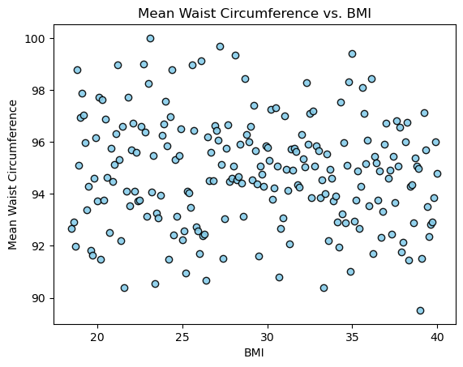

```python
#Creates a scatter plot for the grouped BMI by mean waist circumference
plt.scatter(bmi_waist['BMI'], bmi_waist['Waist_Circumference'], color='skyblue', alpha=0.9, edgecolor ="Black")

# Provides labels
plt.title('Mean Waist Circumference vs. BMI')
plt.xlabel('BMI')
plt.ylabel('Mean Waist Circumference')


plt.show() # Show the graph
```

- Not much correlation between BMI and waist circumference.

## Visualizations: Further Exploration

### Subplots: Gender vs Lifestyle

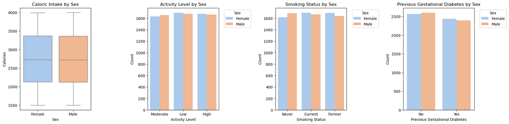

```python
# This creates a 1x4 subplot
fig, axes = plt.subplots(1, 4, figsize=(22, 5))
plt.subplots_adjust(wspace=0.8, hspace=0.4)
# Boxplot for Caloric Intake vs Genders
sns.boxplot(data=df_clean, x='Sex', y='Caloric_Intake', palette='pastel', ax=axes[0])
axes[0].set_title('Caloric Intake by Sex')
axes[0].set_xlabel('Sex')
axes[0].set_ylabel('Calories')

# Countplot for Activity Level vs Gender
sns.countplot(data=df_clean, x='Physical_Activity_Level', hue='Sex', palette='pastel', ax=axes[1])
axes[1].set_title('Activity Level by Sex')
axes[1].set_xlabel('Activity Level')
axes[1].set_ylabel('Count')
axes[1].legend(title='Sex', bbox_to_anchor=(1.05, 1), loc='upper left') #Gets the legend out of the way


# Countplot for Smoking Status vs Gender
sns.countplot(data=df_clean, x='Smoking_Status', hue='Sex', palette='pastel', ax=axes[2])
axes[2].set_title('Smoking Status by Sex')
axes[2].set_xlabel('Smoking Status')
axes[2].set_ylabel('Count')
axes[2].legend(title='Sex', bbox_to_anchor=(1.05, 1), loc='upper left') #Gets the legend out of the way

# Countplot for Previous Gestational Diabetes Countplot vs Gender
sns.countplot(data=df_clean, x='Previous_Gestational_Diabetes', hue='Sex', palette='pastel', ax=axes[3])

axes[3].set_title('Previous Gestational Diabetes by Sex')
axes[3].set_xlabel('Previous Gestational Diabetes')
axes[3].set_ylabel('Count')
axes[3].set_xticklabels(['No', 'Yes'])  # Changing the x-axis labels from binary to No/Yes
axes[3].legend(title='Sex', bbox_to_anchor=(1.05, 1), loc='upper left')  #Gets the legend out of the way
plt.savefig("subplot1.jpg") #Saves image as jpg
plt.show() #Shows graph
```

### Ethnicity and Diabetes Status

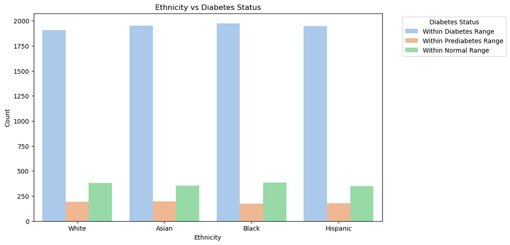

```python
# Created a countplot for Ethnicity vs Diabetes Status, and set the graph's size
plt.figure(figsize=(10, 6))
sns.countplot(data=df_clean, x='Ethnicity', hue='HbA1c_Status', palette='pastel')
# Provides labels
plt.title('Ethnicity vs Diabetes Status')
plt.xlabel('Ethnicity')
plt.ylabel('Count')
plt.legend(title='Diabetes Status', bbox_to_anchor=(1.05, 1), loc='upper left')

plt.savefig("EthDS.jpg") #Saves graph as jpg
plt.show() #Shows the graph
```

- More patients with Black ethnities are diabeteic
- Patients with Asian and Hispanic ehtnities are tied as the second highest to have diabetes
- People of color are disportionately affected

### Subplot: Ethniciy vs Blood Labwork

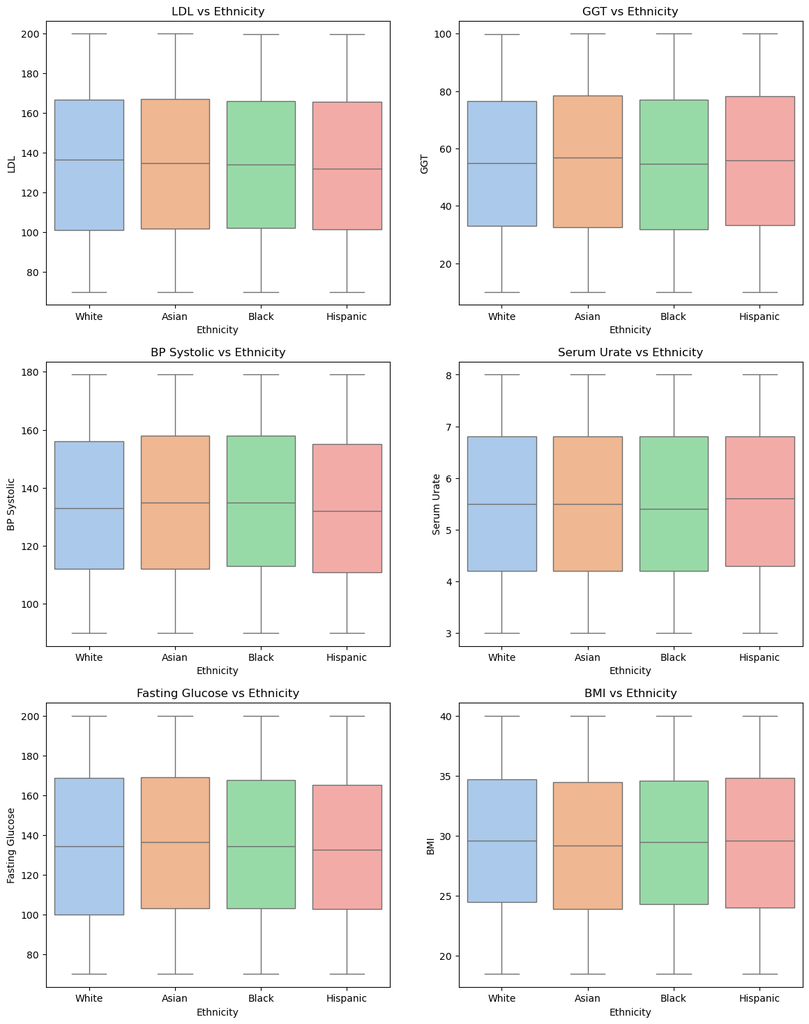

```python
# Creates a 3x2 subplot. All with boxplots
fig, axes = plt.subplots(3, 2, figsize=(14, 18))

# Boxplot for LDL vs Ethnicity
sns.boxplot(data=df_clean, x='Ethnicity', y='Cholesterol_LDL', palette='pastel', ax=axes[0, 0])
axes[0, 0].set_title('LDL vs Ethnicity')
axes[0, 0].set_xlabel('Ethnicity')
axes[0, 0].set_ylabel('LDL')

# Boxplot for GGT vs Ethnicity
sns.boxplot(data=df_clean, x='Ethnicity', y='GGT', palette='pastel', ax=axes[0, 1])
axes[0, 1].set_title('GGT vs Ethnicity')
axes[0, 1].set_xlabel('Ethnicity')
axes[0, 1].set_ylabel('GGT')

# BP Systolic vs Ethnicity
sns.boxplot(data=df_clean, x='Ethnicity', y='BP_Systolic', palette='pastel', ax=axes[1, 0])
axes[1, 0].set_title('BP Systolic vs Ethnicity')
axes[1, 0].set_xlabel('Ethnicity')
axes[1, 0].set_ylabel('BP Systolic')

# Boxplot Serum Urate vs Ethnicity
sns.boxplot(data=df_clean, x='Ethnicity', y='Serum_Urate', palette='pastel', ax=axes[1, 1])
axes[1, 1].set_title('Serum Urate vs Ethnicity')
axes[1, 1].set_xlabel('Ethnicity')
axes[1, 1].set_ylabel('Serum Urate')

# Blood Glucose vs Ethnicity
sns.boxplot(data=df_clean, x='Ethnicity', y='Fasting_Glucose', palette='pastel', ax=axes[2, 0])
axes[2, 0].set_title('Fasting Glucose vs Ethnicity')
axes[2, 0].set_xlabel('Ethnicity')
axes[2, 0].set_ylabel('Fasting Glucose')

# BMI vs Ethnicity
sns.boxplot(data=df_clean, x='Ethnicity', y='BMI', palette='pastel', ax=axes[2, 1])
axes[2, 1].set_title('BMI vs Ethnicity')
axes[2, 1].set_xlabel('Ethnicity')
axes[2, 1].set_ylabel('BMI')

plt.savefig("subplot2.jpg") #Saves graph as jpg
plt.show() #Shows the graph
```

- Hispanic and Asian ethnities have higher medians and higher quartile for GGT
- White ethnities have higher LDLs compared to the rest
- The median of the BMI for each ethnicity is quite similar. However, for the White and Hispanic ethnicities, they have the highest medians compared to the others.
- An interesting finding, is that the Hispanic ethnicity has lower fasting glucose then the rest, but have high A1c.
- Asian and Black patients in the dataset have a higher median and upper quartile for their systolic blood pressure. Therefore, they have higher chance of having hypertension then the rest.
- The Serum Urate boxplot is very similar. However, black patients in the dataset have a lower median in their boxplot. Serum Urate is important to look out for because high levels can increase your risk of Type 2 Diabetes

### HbA1c vs Blood Pressure

```python
#Creates an interactive scatterplot with HbA1c and BP_Systolic
fig = px.scatter(df_clean, x= 'HbA1c', y='BP_Systolic', color='Blood_Pressure_Status', title='Hb1AC vs BP Systolic by Blood Pressure Status', hover_data= ['HbA1c_Status'])
fig.update_layout(width=1200,height=800)
fig.show() #Shows the graph
```

[interactive chart not shown]

- Graph is sort of messy. However, it shows that there is not a clear correlation between values.

```python
#Here, the BP_Systolic was grouped with the mean of HbA1c to create a cleaner graph
df_grouped = df_clean.groupby('BP_Systolic')['HbA1c'].mean().reset_index()

#This had to be merged back to the database. I had helped from googling to do this.
df_merged = df_clean.merge(df_grouped, on='BP_Systolic', suffixes=('', '_mean'))

# #This creates the scatter plot with the grouped variable
fig = px.scatter(df_merged, x='HbA1c_mean', y='BP_Systolic', color='Blood_Pressure_Status', title='Mean HbA1c vs BP Systolic by Blood Pressure Status',
                hover_data= ['HbA1c_Status'])

fig.show() #Shows the graph
```

[interactive chart not shown]

```python
fig.write_html("interactive_plot1.html") #saves the interactive plot.
```

- The outliers showed that the majority of the patients with very high A1c had stage 2 hypertension or elevated blood pressures.